# Научная презентация по лабораторной работе №7

Дисциплина:Операционные системы

Абрамова У. М.

Российский университет дружбы народов, Москва, Россия

Математический институт имени Никольского, Москва, Россия

29.03.2025

# Информация

## Докладчик

- Абрамова Ульяна Михайловна
- Студент НММбд-01-24
- Российский университет дружбы народов
- 1132246782@pfur.ru
- https://github.com/Ulyana-abr

# Вводная часть

## Актуальность

- Работа с файловой системой актуальна, так как без неё не может работать ни один компьютер. Файловая система отвечает за оптимальное логическое распределение информационных данных на конкретном физическом носителе.

## Цели и задачи

- Ознакомление с файловой системой Linux, её структурой, именами и содержанием каталогов.
- Приобретение практических навыков по применению команд для работы с файлами и каталогами, по управлению процессами (и работами), по проверке исполь- зования диска и обслуживанию файловой системы.

## Материалы и методы

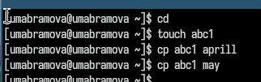

копирование файла в текущем каталоге

## Содержание исследования

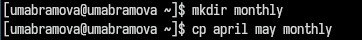

копирование нескольких файлов в каталог

## Содержание исследования

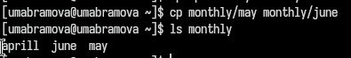

копирование файлов в произвольном каталоге

## Содержание исследования

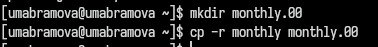

копирование каталогов в текущем каталоге

## Содержание исследования

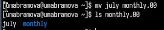

перемещение файлов в другой каталог

## Содержание исследования

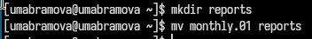

перемещение каталога в другой каталог

## Содержание исследования

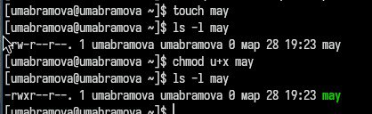

изменение прав доступа

## Содержание исследования

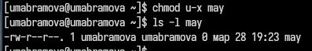

изменение прав доступа

## Содержание исследования

2. Выполнение различных действий с файлами и каталогами

Копирую файл в домашний каталог и называю его equipment (рис. 15)

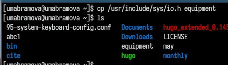

копирование и переименование

## Содержание исследования

В домашнем каталоге создаю директорию, перемещаю ранее созданный файл в каталог, переименовываю его (рис. 16)

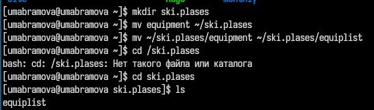

создание, перемещение и переименование

## Содержание исследования

Создаю в домашнем каталоге файл abc1 и копирую его в созданный до этого каталог (рис. 17)

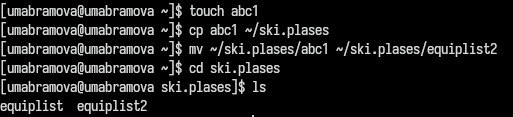

создание и копирование

## Содержание исследования

В том же каталоге создаю каталог equipment, в который перемещаю файлы equiplist1, 2 (рис. 18)

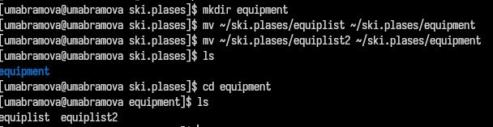

создание и перемещение

## Содержание исследования

В домашнем каталоге создаю каталог newdir, перемещаю его в использованный до этого каталог и задаю новое имя plans (рис. 19)

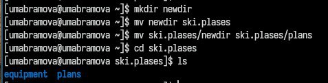

создание, перемещение и перименование

## Содержание исследования

3. Использование команды chmod с различными опциями Создаю нужные файлы и определяю какие опции chmod необходимы, чтобы присвоить файлам определенные права доступа (рис. 20)

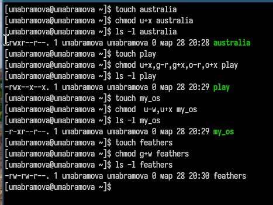

опции команды chmod

## Содержание исследования

4. Проделывание упражнений С помощью команды cat просматриваю содержимое файла /etc/passwd (рис.21)

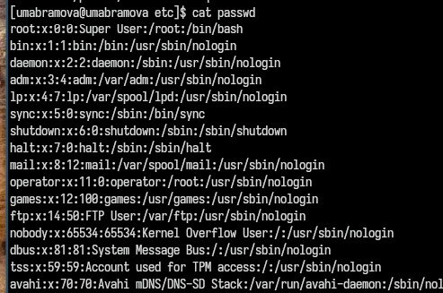

просмотр содержимого файла

## Содержание исследования

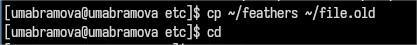

## Содержание исследования

Перемещаю каталог fun в каталог play и задаю новое имя games (рис. 23)

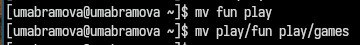

перемещение и переименование

## Содержание исследования

Лишаю владельца файла feathers право на чтение (рис. 24)

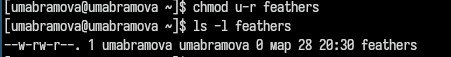

команда chmod

## Содержание исследования

В результате чего не получается не получается просмотреть файл командой cat, а также скопировать данный файл (рис. 25)

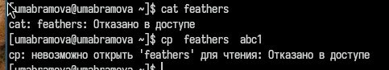

результат лишения права владельца на чтение

## Содержание исследования

Лишаю владельца каталога play права на выполнение, из-за чего не получается перейти в него (рис. 26)

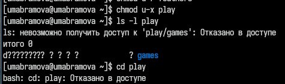

команда chmod

## Содержание исследования

5. Использование команды man Использую команду man по командам mount, fsck, mkfs, kill (рис. 27, 28, 29,30).

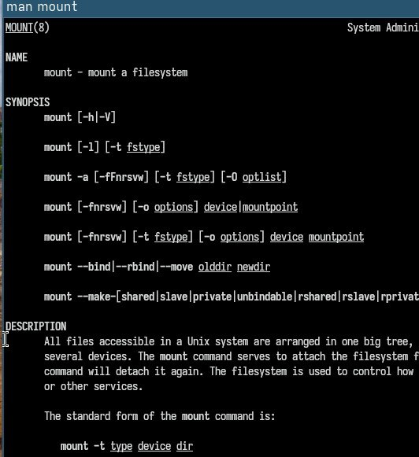

mount

## Содержание исследования

Команда mount используется для монтирования файловой системы. Она принимает два параметра: файл устройства, соответствующий диску или разделу, на котором расположена файловая система, и имя каталога, к которому будет монтироваться система. Например, чтобы смонтировать дискету MS-DOS, нужно выполнить команду:

mount -t msdos /dev/fd0 /floppy

## Содержание исследования

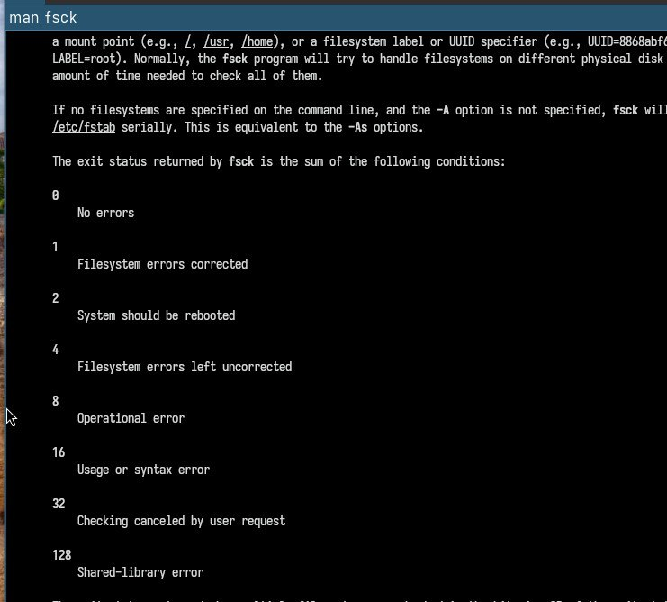

fsck

## Содержание исследования

Команда fsck служит для проверки целостности и работоспособности файловой системы. Большинство систем сконфигурировано так, что команда fsck запускается автоматически при загрузке системы. Например, чтобы проверить диск /dev/sda6, нужно выполнить команду:

sudo fsck -a /dev/sda6

## Содержание исследования

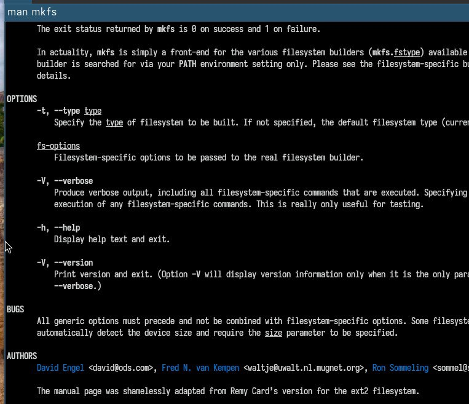

mkfs

## Содержание исследования

Команда mkfs позволяет создать файловую систему Linux. Например, чтобы отформатировать раздел с файловой системой ext4, можно выполнить команды:

mkfs.ext4 /dev/sdb3

## Содержание исследования

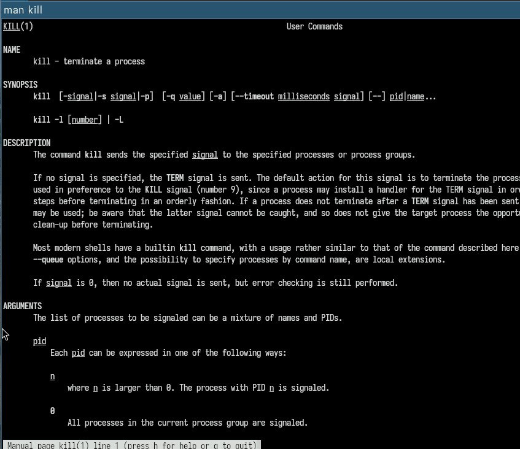

kill

## Содержание исследования

Команда kill используется для завершения процессов. Например, чтобы корректно завершить процесс с PID 98989, нужно выполнить команду:

kill -TERM 98989

## Итоговый слайд

- Чем больше вы практикуетесь и пробуете новое, тем больше и чаще вы будете получать знаний и опыта в разных сферах.